# trackeR - Infrastructure for Running and Cycling Data in R

28 June 2016

## Introduction

Outline

- Motivation
- Functionality of trackeR
- Code examples and implementation detail

Questions to answer in the next 15 minutes:

- Why care?
- What can you do with trackeR?
- How does it work?

## Motivation

- Increasing amount of fitness and sports data from GPS-enabled tracking devices.
- Proprietary software for analysis from device manufacturers and various apps.
- Open-source software [Golden Cheetah](http://goldencheetah.org) for cycling analysis.
- Typically tools for descriptive analysis, unlike the many opportunities in R.
- trackeR aims to bridge the gap between the routine collection of such data and their analysis in R.
- Relatively few R packages related to sports: sport management, ranking teams, scraping betting odds, etc and cycleRtools/elpatron for cycling data.

## Package structure

[interactive chart not shown]

## What can you do?

- Read data from Training Center XML (TCX) files, SQLite databases and Golden Cheetah JSON files.
- Store the data in session-based, unit- and operation-aware objects of class *trackeRdata*.
- Basic operations: summarise, plot, handle units, etc.
- Analyse time in zones, work capacity above critical power/speed, distribution of training time.
- Utilise the rich tool set of statistical methodology provided in R base and other packages.

## Read data

[figure not shown]

## Read data

```r
library("trackeR")
filepath <- system.file("extdata", "2013-06-08-090442.TCX",
                        package = "trackeR")
runDF <- readTCX(file = filepath, timezone = "GMT")
str(runDF)
```

```
## 'data.frame':    1191 obs. of  9 variables:
##  $ time      : POSIXct, format: "2013-06-08 08:04:42" ...
##  $ latitude  : num  51.4 51.4 51.4 51.4 51.4 ...
##  $ longitude : num  1.04 1.04 1.04 1.04 1.04 ...
##  $ altitude  : num  6.2 6.2 6.2 6.2 6.2 ...
##  $ distance  : num  0 1.68 5.28 8.33 14.88 ...
##  $ heart.rate: num  83 84 84 86 89 93 96 98 101 102 ...
##  $ speed     : num  0 0.594 1.416 1.928 2.614 ...
##  $ cadence   : num  NA 54 74 97 97 97 97 98 97 97 ...
##  $ power     : num  NA NA NA NA NA NA NA NA NA NA ...
```

## Read data

```r
runTr0 <- trackeRdata(runDF)
runTr1 <- readContainer(filepath, type = "tcx", timezone = "GMT")
identical(runTr0, runTr1)
```

```
## [1] TRUE
```

```r
runTr2 <- readDirectory(system.file("extdata", package = "trackeR"),
                        timezone = "GMT")
```

```
## Reading file /home/frick/lib/R/trackeR/extdata/2013-06-08-090442.TCX (file 1 out of 1) ...
## Cleaning up...Done
```

```r
identical(runTr0, runTr2)
```

```
## [1] TRUE
```

## Session-based data structure

- Very basic data cleaning: no missing time stamps, heart rate of 0 set to NA.
- Split observations in sessions based on ordered time stamps: any observations further apart than a threshold (default: 2 hours) are considered to be in different sessions.
- Short gaps in recordings can occur within sessions, usually due to a reduced sampling rate or to the device being paused. We impute zero speed/power during such periods.
- Store each session in a multivariate **zoo** object.
- A **trackeRdata** object is a list of session objects with attributes for units of measurement and operations such as smoothing.

## Example data

- 27 sessions by a male runner in June 2013 available via

```r
data("runs", package = "trackeR")
```

- Different visualisations available

```r
plot(runs, session = c(3,13))
plotRoute(runs, session = 3, source = "osm")
leafletRoute(runs, session = c(6,7,10,12,13,21))
```

## Visualise sessions

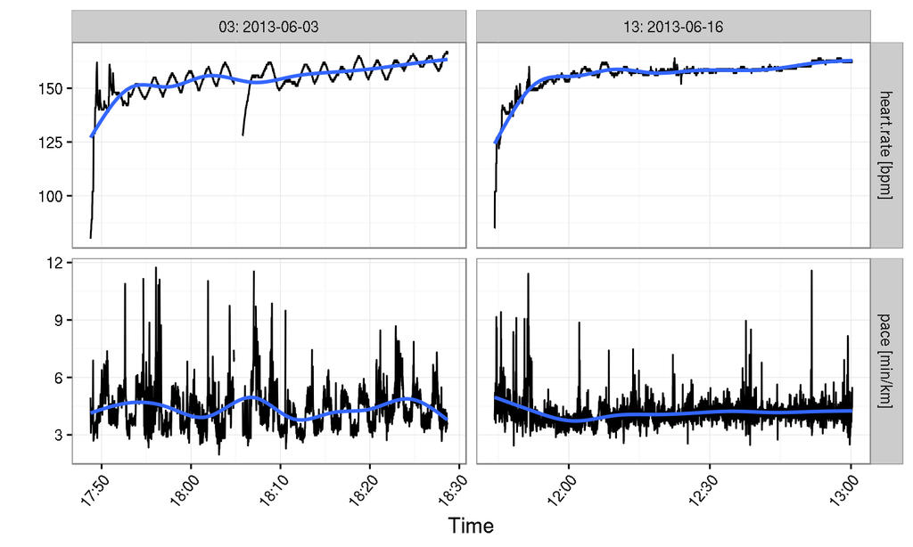

## Visualise sessions

[figure not shown]

## Visualise sessions

[interactive chart not shown]

## Summarise sessions

```r
summary(runs, session = 1)
```

```
##  *** Session 1 ***
##
##  Session times: 2013-06-01 17:32:15 - 2013-06-01 18:37:56
##  Distance: 14130.7 m
##  Duration: 1.09 hours
##  Moving time: 1.07 hours
##  Average speed: 3.59 m_per_s
##  Average speed moving: 3.67 m_per_s
##  Average pace (per 1 km): 4:38 min:sec
##  Average pace moving (per 1 km): 4:32 min:sec
##  Average cadence: 88.66 steps_per_min
##  Average cadence moving: 88.87 steps_per_min
```

## Summarise sessions

```
##  Average power: NA W
##  Average power moving: NA W
##  Average heart rate: 141.11 bpm
##  Average heart rate moving: 141.13 bpm
##  Average heart rate resting: 136.76 bpm
##  Work to rest ratio: 42.31
##
##  Moving threshold: 1 m_per_s
```

```r
runsSummary <- summary(runs)
plot(runsSummary, what = c("avgSpeed", "distance"))
```

## Summarise sessions

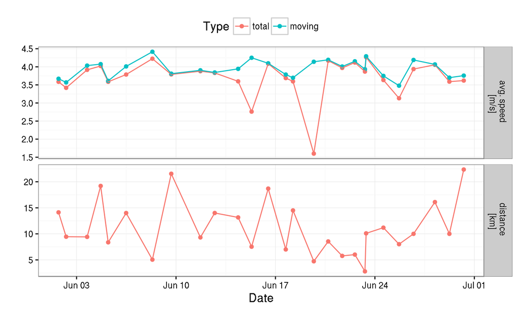

## Distribution and concentration profiles

Summarise sessions with regard to speed, heart rate, etc:

- Via time spent above a (single) arbitrary threshold such as maximum aerobic speed.
- Via time in zones, i.e., the differences of time spent above a set of thresholds.
- Extend this idea: a **distribution profile** is a function of the threshold, returning the time spent exercising above that threshold (Kosmidis and Passfield, 2015).
- A **concentration profile** is the negative first derivative of the distribution profile, revealing concentrations around certain speeds, heart rates, etc.

## Illustration

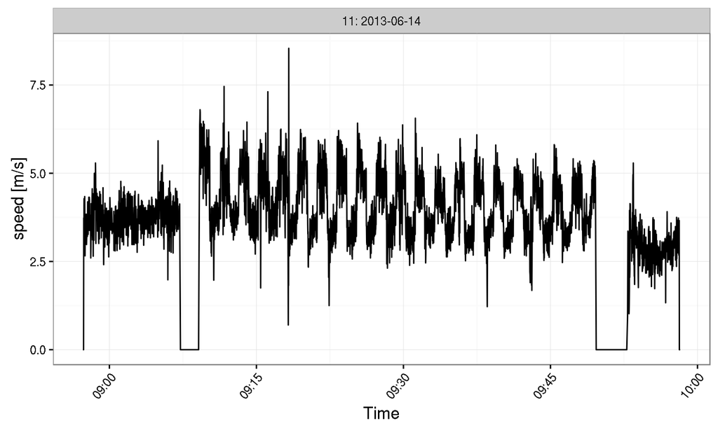

## Illustration

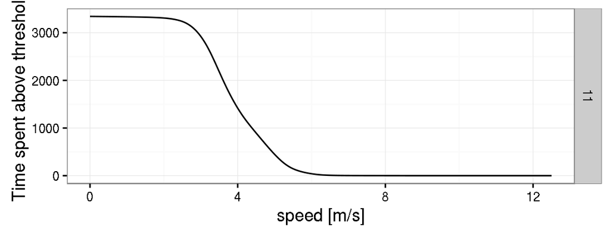

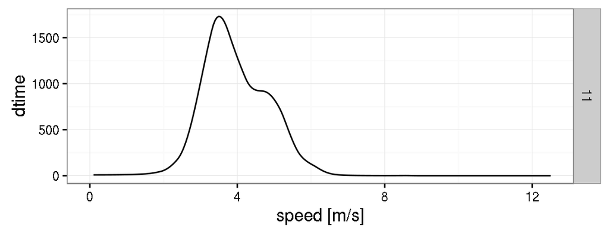

## Distribution and concentration profiles

```r
## Change speed unit to miles per hour
runs <- changeUnits(runs, variable = "speed", unit = "mi_per_h")
```

```r
## Calculate and plot distribution profiles
dProfiles <- distributionProfile(runs, what = "speed",
  grid = seq(0, 22, by = 0.1))
plot(dProfiles, multiple = TRUE)
```

```r
## Calculate and plot concentration profiles
cProfiles <- concentrationProfile(dProfiles)
plot(cProfiles, multiple = TRUE)
```

```r
## Functional principal components analysis (PCA)
cpPCA <- funPCA(cProfiles, what = "speed", nharm = 4)
plot(cpPCA, harm = 1:2)
```

## Distribution and concentration profiles

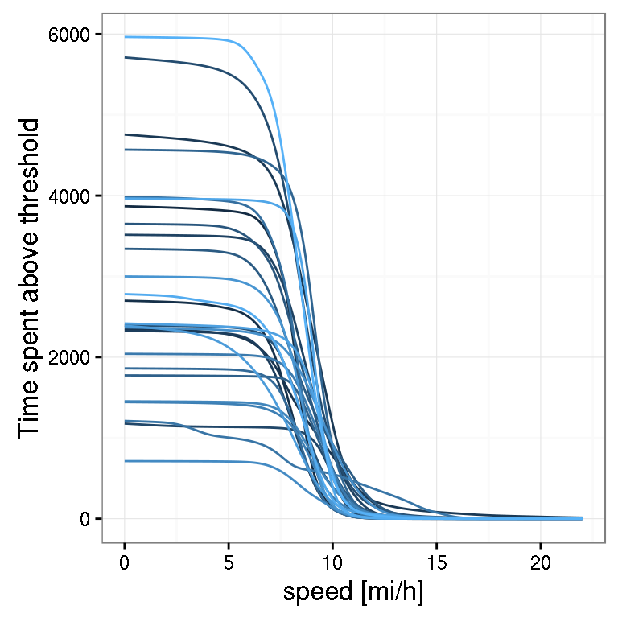

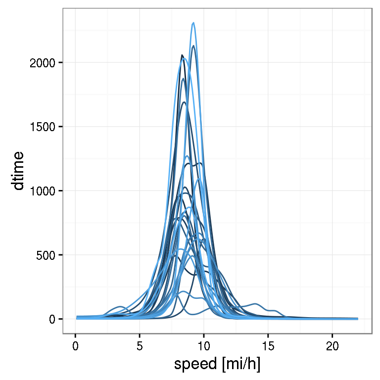

## Functional PCA

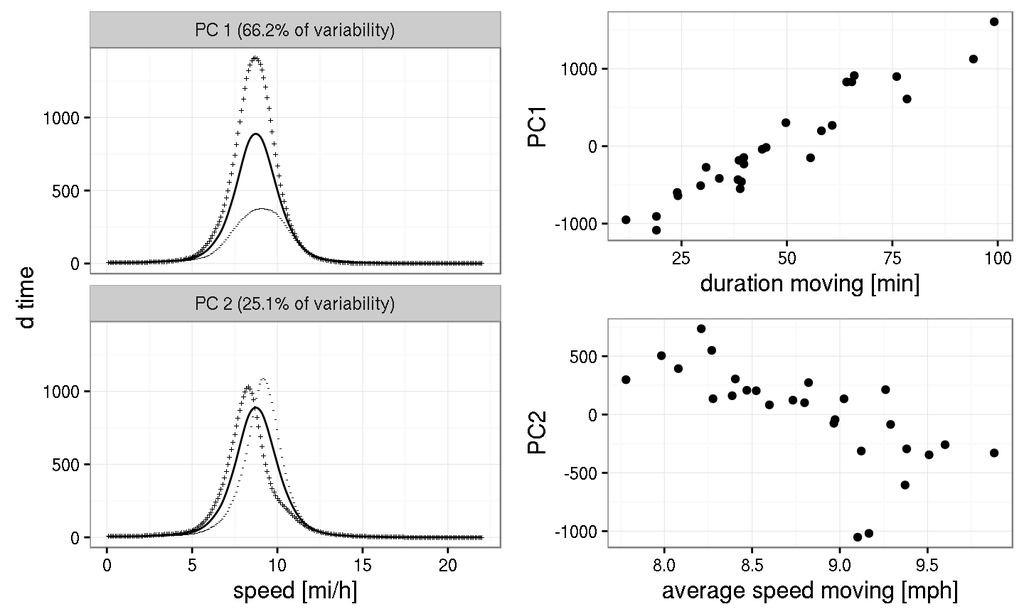

## Summary

- Motivation: bring fitness and sports tracking data to the analytic capacity of R.
- Functionality: Read data, session-based data structure, basic analytic tools and visualisations.
- Available from **CRAN** and **GitHub**:
  - http://cran.r-project.org/package=trackeR
  - http://www.github.com/hfrick/trackeR
- Further information in vignettes:
  - *trackeR*: more details on implementation.
  - *Tour de trackeR*: a brief tour of functionality.
- Future work: more input formats, stronger link with Golden Cheetah, incorporate team structure, …

## References

- Kosmidis I, Passfield L (2015). "Linking the Performance of Endurance Runners to Training and Physiological Effects via Multi-Resolution Elastic Net." ArXiv e-print arXiv:1506.01388.
- Zeileis A, Grothendieck G (2005). "zoo: S3 Infrastructure for Regular and Irregular Time Series." Journal of Statistical Software, 14(6), 1-27.
- Wickham H (2009). "ggplot2: Elegant Graphics for Data Analysis." Springer-Verlag New York.
- Ramsay JO, Silverman BW (2005). "Functional Data Analysis." Springer-Verlag New York.
- Pya N, Wood SN (2015). "Shape Contrained Additive Models." Statistics and Computing, 25(3), 543-559.